# Final Project Overview & Instructions

Data Science 1 with R (STAT 301-1)

Author

INSTRUCTIONS

## Overview

Recall that the main objective for this course is to build foundational analytic skills and knowledge necessary to conduct data science. In particular, the focus has been on the development of essential skills necessary for conducting data science, such as data management, manipulation, and visualization.

Therefore, the final project is designed for students to demonstrate their understanding and mastery of these data science skills by conducting an exploratory data analysis on a dataset(s) of their own choosing.

Ideally, this project will be the start of a data science portfolio which can be used as evidence of your acquired skills and knowledge.

## Task

Each student will seek out and collect/create a **sufficiently complex** dataset and perform an exploratory data analysis (EDA). Students are not allowed to use data from existing R packages — unless it is to augment their own data. Each student should strive to conduct and produce their own “original” EDA. This does not exclude mimicking other EDAs, attempting to re-create an EDA, conducting a similar EDA on an updated version of similar data, or augmenting a existing EDA with additional data.

**What does **sufficiently complex** data mean?**

This really depends on the project and nature of the data involved. The complexity might be involved in how the data is gathered, like having to use web scrapping to collect data, it could be a mix of variable types that includes a lot of string and date variables, or it could be having to figure our how to join/merge several data tables.

A single csv download of a dataset with 10 variables and less than 1,000 observations is *probably* not complex enough. Especially if the variables are all of one type.

Balancing this is always a little tricky, but that is why Progress Memo 1 is so important.

**Why does having **sufficiently complex** matter?**

Students need to demonstrate their mastery of course materials. A lack of complexity will not provide a broad enough set of opportunities. We need to see students are able to apply concepts and tools covered throughout the quarter.

Similarly, a lack of complexity will significantly hinder the usefulness of including the project as part of a “Data Science Portfolio” or a resume.

## Final Project Core Components

### Project Memos

#### Progress Memo 1

The initial step of the final project starts with each student submitting Progress Memo 1. In this memo students will

1. Identify the data they plan to use for their EDA/Final Project,
2. Set up their GitHub repository for the Final Project, and
3. Demonstrate that they can import their data or parts of their data into R.

The memo should contain appropriate data citations and data quality and complexity checks. Students will be graded on the quality of their memo and whether they meet the memo requirements.

A part from grading, instructors will provide feedback concerning the appropriateness of the selected dataset(s) — meaning an assessment of data complexity and appropriateness for the an EDA project. Instructors will either provide clear approval, cautious approval (there are concerns), a request for students to provide more details before approval is granted, or indicate the dataset(s) is not appropriate for the final project.

#### Progress Memo 2

Students are expected to demonstrate that *significant* progress has been made on their final project since the submission of progress memo 1. Students should have their data cleaned and the EDA should be started.

Demonstrating significant progress means students should have some univariate and bivariate analyses complete for several of their variables. Students should summarize their progress and where they are at and what their next steps will be. They should share a few graphics and/or tables with a description of what they have found thus far to demonstrate they progress. Students should should clearly state what they are exploring and why in these demonstrations. That is, they should share the guiding curiosity or research question that accompanies the particular graphics and/or tables they choose to share. They can also share any guiding curiosities or research questions they plan to explore.

### Project structure

This is an extremely important part of the project and one of the main learning objectives of this course.

Basic structure:

- Your project should be well organized and easy to navigate (see Figure 1 below).
- Must be using GitHub and working in an RStudio project!
- GitHub `README.md`s should be used. They work as landing pages for important directories/folders such as the home directory and data folders. They should be used to provide an overview of what is found in the folder — think basic table of contents and important info to note.
- There should be at least a `data/` sub-directory/folder containing the important forms of data, codebooks, and citations — should have a sub-directory `raw` containing the original form of the data (see Figure 2 below). Some projects have unique data issues that will be worked out with the instructor, but this is where students should note these in their project.
- R scripts should be obviously named and easy to follow. They should follow a useful naming convention that orders and thoughtfully organizes the work as demonstrated in the image below.
- Memos, report, and executive summary should also be appropriately named and contained in the project.

#### Example

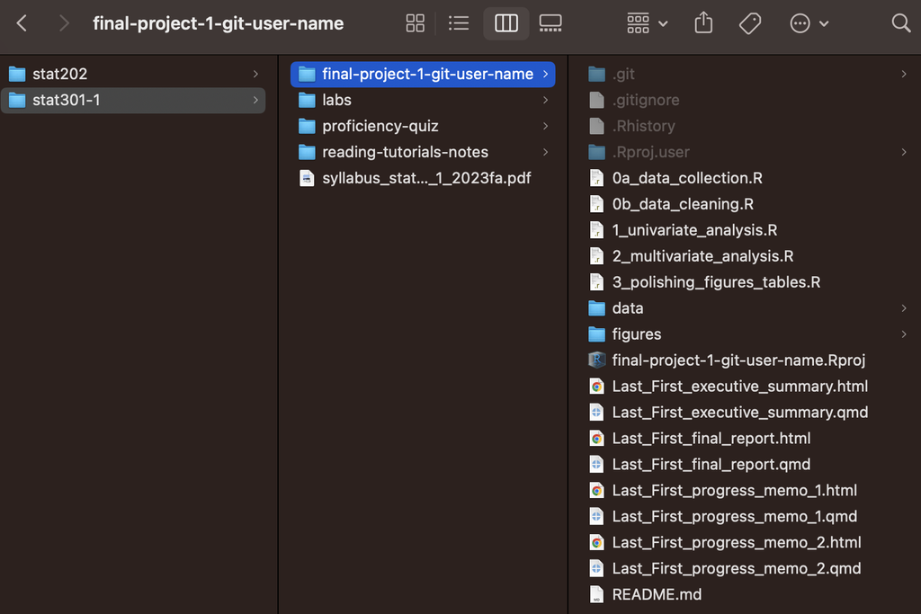

Figure 1: Possible Structure for the Final Project: Home/Main Directory

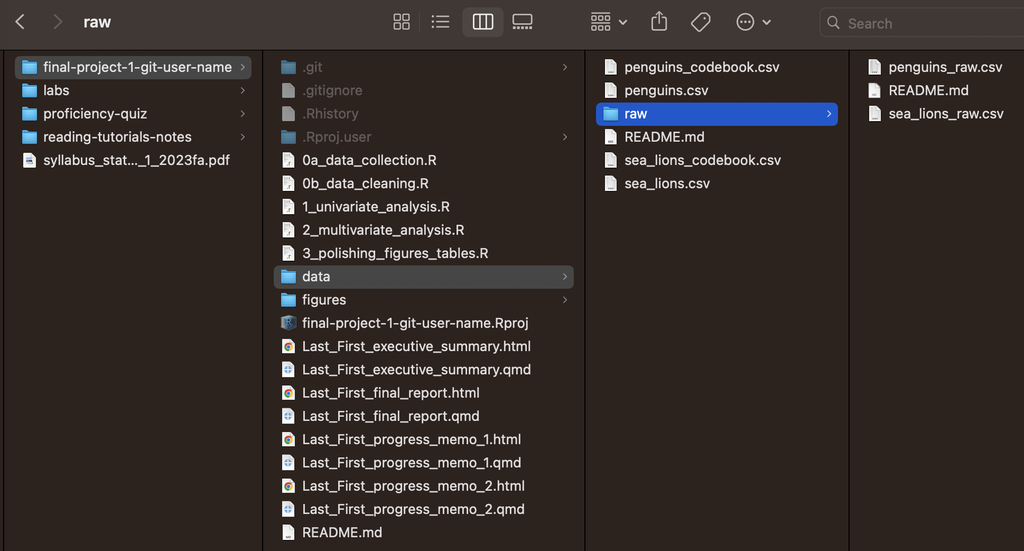

Figure 2: Possible Structure for the Final Project: Data Sub-directory

**Important**

Please note this example project structure is a **guideline**. There are other structures/organizations that are perfectly acceptable. However, it must be straight-forward to understand and navigate.

For example, the number of R scripts and subsequent numbering used in their names really depends on the project. If you start with easily obtained/collected data, then maybe there won’t be a need for data collection script. Analysis scripts might be organized around specific variables instead of the number of variables in the analysis: `1a_variable1.R`, `1b_variable2.R`, etc. Could setup more sub-directories/folders to partition the work, such are having `scripts/` containing all R scripts or `memo_1/` containing memo 1 material.

### Report

This is a report and should read as such, meaning it should be well organized, clearly articulated (good narrative), and flow in a logical manner.

Some basics:

- There should not be sequences of plots or tables without any explanation.
- There should be absolutely no code in your report **— don’t hide it; code should not be visible/accessible**.
- There should be no tibbles/data frames or raw R output — should use tables (avoid unnecessarily long output)!
- Any plots or graphics should be polished (appropriate labels and/or captions).
- All figures and tables should be properly labeled and referenced — **must make use of quarto cross-referencing**.
- There should be a unique title that is appropriate for your project (“301-1 Final Project” is not a good title), author, and date.
- Should use heading and sub-headings appropriately.
- Should include a link to project’s GitHub repo.

Your report will likely contain some variation of the section listed below. The actual sections names can be modified as long as it is fitting for the section. Where appropriate, subsections should be used.

- Link to GitHub Repo — use callout box
- Introduction
- Data overview & quality
- Explorations
- Conclusion
- References — if needed
- Appendix: technical info — if needed
- Appendix: extra explorations — if needed

#### Introduction

Overview of the EDA. What was the motivation for this analysis? What initial curiosities or research questions motivated you? Describe the data source(s) you will use to build a predictive model. If you are obtaining information from websites you should cite those in your **References**.

#### Data overview & quality

A concise high level overview of the dataset(s) being explored. Description of the dataset(s) that covers basics: size, number of observations, number, of variables, variable types, and discussion of any quality issues (especially missingness and how it may impact the analysis). Highlight any important data collection issues or concerns. If over-technical, but important, then place technical details in **Appendix: technical info**.

#### Explorations

This is the heart or main body of the the report. The structure of this portion can look **VERY** different depending on narrative choices and organization choices made to guide readers through the project EDA. Could decide to make sections for major parts of the EDA and not used an **Explorations** header. The key is that you have sections that are clearly organized and guide the reader through a systematic and thoughtful exploration of the dataset(s).

A thoughtful exploration weaves together prose, figures, and tables to help a reader build understanding. It is a guided tour that should have clear motivations for each step in the process (think guiding curiosities or research questions). It should be clear how things build of of each other and why we are looking at what is being presented. Should also be letting the reader know whether what is shown is as expected or is it surprising (maybe some of each).

You could imagine structuring this section around analysis type: univariate, bivariate, and multivariate. Can be a little harder to build a narrative with this structure. Could build sections that are dedicated to important variables: variable 1, variable 2, etc. In this case the sections would thoroughly explore the section’s variable through univariate, bivariate, and multivariate analyses. Alternatively, could build your sections around broad curiosities/research questions. Some of which probably inspired the project, and others that were developed through conducting the EDA.

#### Conclusion

State conclusions or insights. Were you surprised by things you found or were they as expected? Why? This is a great place for future work, new research questions, and next steps.

#### References — if needed

Any references used should be sited here. This includes but is not limited to where you got your data. There is no “formal” reference guideline but we recommend APA format. Example: Last name, F. M. (Year, Month Date). *Title of page*. Site name. URL

#### Appendix: technical info — if needed

A place to share complex and important technical steps that may highly impact explorations, but the details are too technical to share in main body of the report.

#### Appendix: extra explorations — if needed

Useful in cases where there are an **over-abundance** of explorations and they are not useful in the main body of the report or they are uninteresting, but still think readers should have access to them for reference.

### Executive Summary

An executive summary should summarize the key points of the report. It should restate the purpose of the report, highlight the major results, and summarize any conclusions. This report should be concise and clearly written. If you are unsure how to [write an Executive Summary](https://writingcenter.uagc.edu/writing-executive-summary#:~:text=An%20executive%20summary%20should%20summarize,or%20recommendations%20from%20the%20report.) there are a lot of resources on the internet! Consider visiting the [writing center](https://www.writing.northwestern.edu/) if you need help.

## Project Rubric

| Project Memos | 0😱 | 2 😨 | 4😦 | 6 😕 | 8🙂 | 10 🤩 |
| --- | --- | --- | --- | --- | --- | --- |
| Progress Memo 1 | Non existent |  |  |  |  | All requirements met |
| Progress Memo 2 | Non existent |  |  |  |  | All requirements met |

[output not shown]

[output not shown]

[output not shown]

| Total |  |  |  |  |  | /100 |
| --- | --- | --- | --- | --- | --- | --- |